# DC motor drive

A single-phase fully controlled AC-DC converter feeds a separately excited DC motor. The parameters of the DC motor are $R_a=0.4\,\Omega$, $L_a=0.5\,$H, $K_T=0.5\,$N-m/A, $J=0.001\,$kg-m$^2$, $B=0.001\,$N-m-s/rad. The rated voltage of the motor is $200\,$V DC, and the rated torque is $1\,$N-m. The grid voltage is $230\,$V, $50\,$Hz. Determine the following if the rated voltage and torque are applied to the motor.

1. Firing angle of the converter,
2. Average motor current,
3. Speed of motor,
4. RMS source current,
5. Source power factor,
6. THD in the source current,
7. Harmonic content in the electromagnetic torque.

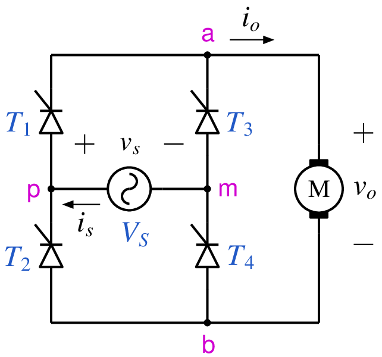

```python
from IPython.display import Image
Image(filename =r'dcmc_1_fig_1.png', width=250)
```

```python
# run this cell to view the circuit file.
%pycat dcmc_1_orig.in
```

We now replace the strings such as `\$La` with the values of our choice by running the python script given below. It takes an existing circuit file `dcmc_1_orig.in` and produces a new circuit file `dcmc_1.in`, after replacing `\$La` (etc) with values of our choice.

```python
import gseim_calc as calc
import numpy as np

Vm_ac = 230.0*np.sqrt(2.0)
s_Vm_ac = ("%11.4E"%Vm_ac).strip()
s_Ra = "0.4"
s_La = "0.5"
s_k_e = "0.5"
s_J = "0.001"
s_b_damp = "0.001"
s_TL = "1"
s_alpha = "25.0" # to be changed by user

l = [
  ('$Vm_ac', s_Vm_ac),
  ('$Ra', s_Ra),
  ('$La', s_La),
  ('$k_e', s_k_e),
  ('$J', s_J),
  ('$b_damp', s_b_damp),
  ('$TL', s_TL),
  ('$alpha', s_alpha),
]
calc.replace_strings_1("dcmc_1_orig.in", "dcmc_1.in", l)
print('dcmc_1.in is ready for execution')
```

```
dcmc_1.in is ready for execution
```

**Execute the following cell to run GSEIM on dcmc_1.in.**

```python
import os
import dos_unix
# uncomment for windows:
#dos_unix.d2u("dcmc_1.in")
os.system('run_gseim dcmc_1.in')
```

```
Circuit: filename = dcmc_1.in
main: calling solve_sss
solve_sss starting: sss_n_st: 2
solve_sss_ex: sss_iter_newton=0, rhs_sss_norm=7.3860e+01, sss_period_1_compute=4.0000e-02
solve_sss_ex: sss_iter_newton=1, rhs_sss_norm=4.7658e+01, sss_period_1_compute=4.0000e-02
solve_sss_ex: sss_iter_newton=2, rhs_sss_norm=3.7152e-11, sss_period_1_compute=4.0000e-02
solve_sss_ex: calling sss_solve_trns_ex for one more trns step
Transient simulation starts...
i=0
i=1000
i=2000
GSEIM: Program completed.
```

```
0
```

```
filename: dcmc_1_1.dat
filename: dcmc_1_2.dat
rms value of i_s:  2.7731E+00
average value of i_dcmc:  2.7452E+00
average value of v_dcmc:  1.8767E+02
average value of tem:  1.3726E+00
average value of wrm:  3.7261E+02
source power factor:  8.0819E-01
```

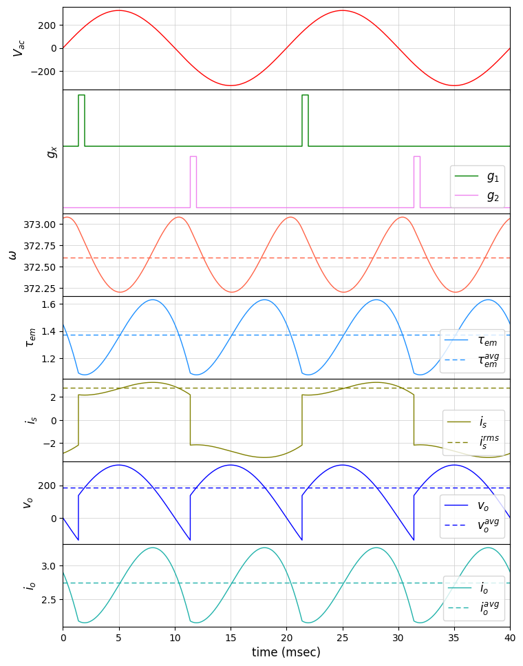

```python
import numpy as np
import matplotlib.pyplot as plt
import gseim_calc as calc
from setsize import set_size

f_hz = 50.0
T = 1.0/f_hz

slv = calc.slv("dcmc_1.in")

i_slv = 0
i_out = 0
filename = slv.l_filename_all[i_slv][i_out]
print('filename:', filename)
u1 = np.loadtxt(filename)
t1 = u1[:, 0]

v_s    = slv.get_array_double(i_slv,i_out,"v_s",u1)
i_s    = slv.get_array_double(i_slv,i_out,"i_s",u1)
tem    = slv.get_array_double(i_slv,i_out,"tem",u1)
wrm    = slv.get_array_double(i_slv,i_out,"wrm",u1)
v_dcmc = slv.get_array_double(i_slv,i_out,"v_dcmc",u1)
i_dcmc = slv.get_array_double(i_slv,i_out,"i_dcmc",u1)

i_out = 1
filename = slv.l_filename_all[i_slv][i_out]
print('filename:', filename)
u2 = np.loadtxt(filename)
t2 = u2[:, 0]

g1 = slv.get_array_double(i_slv,i_out,"g1",u2)
g2 = slv.get_array_double(i_slv,i_out,"g2",u2)
IT1 = slv.get_array_double(i_slv,i_out,"IT1",u2)
IT2 = slv.get_array_double(i_slv,i_out,"IT2",u2)
IT3 = slv.get_array_double(i_slv,i_out,"IT3",u2)
IT4 = slv.get_array_double(i_slv,i_out,"IT4",u2)

p_s = i_s*v_s

l_i_s    = calc.avg_rms_3a(t1, i_s   , 0, 2.0*T, 1.0e-5*T)
l_v_s    = calc.avg_rms_3a(t1, v_s   , 0, 2.0*T, 1.0e-5*T)
l_p_s    = calc.avg_rms_3a(t1, p_s   , 0, 2.0*T, 1.0e-5*T)
l_i_dcmc = calc.avg_rms_3a(t1, i_dcmc, 0, 2.0*T, 1.0e-5*T)
l_v_dcmc = calc.avg_rms_3a(t1, v_dcmc, 0, 2.0*T, 1.0e-5*T)
l_tem    = calc.avg_rms_3a(t1, tem   , 0, 2.0*T, 1.0e-5*T)
l_wrm    = calc.avg_rms_3a(t1, wrm   , 0, 2.0*T, 1.0e-5*T)

Pavg = l_p_s[0]
Irms = l_i_s[1]
Vrms = l_v_s[1]
pf_s  = Pavg/(Vrms*Irms)

print('rms value of i_s:'       , "%11.4E"%l_i_s   [1])
print('average value of i_dcmc:', "%11.4E"%l_i_dcmc[0])
print('average value of v_dcmc:', "%11.4E"%l_v_dcmc[0])
print('average value of tem:'   , "%11.4E"%l_tem   [0])
print('average value of wrm:'   , "%11.4E"%l_wrm   [0])
print('source power factor:'    , "%11.4E"%pf_s)

fig, ax = plt.subplots(7, sharex=False,  gridspec_kw={'height_ratios': [1, 1.5, 1, 1, 1, 1, 1]})
plt.subplots_adjust(wspace=0, hspace=0.0)

set_size(6.5, 9, ax[0])

for i in range(7):
    ax[i].set_xlim(left=0.0, right=2.0*T*1e3)
    ax[i].grid(color='#CCCCCC', linestyle='solid', linewidth=0.5)

for i in range(6):
    ax[i].tick_params(labelbottom=False)

ax[0].set_ylabel(r'$V_{ac}$'   , fontsize=12)
ax[1].set_ylabel(r'$g_x$'      , fontsize=12)
ax[2].set_ylabel(r'$\omega$'   , fontsize=12)
ax[3].set_ylabel(r'$\tau_{em}$', fontsize=12)
ax[4].set_ylabel(r'$i_s$'      , fontsize=12)
ax[5].set_ylabel(r'$v_o$'      , fontsize=12)
ax[6].set_ylabel(r'$i_o$'      , fontsize=12)

color1 = "red"
color2 = "green"
color3 = "violet"
color4 = "tomato"
color5 = "dodgerblue"
color6 = "olive"
color7 = "blue"
color8 = "lightseagreen"

ax[0].plot(t1*1e3, v_s, color=color1, linewidth=1.0, label="$V_{ac}$")

ax[1].plot(t2*1e3, (g1      ), color=color2, linewidth=1.0, label="$g_1$")
ax[1].plot(t2*1e3, (g2 - 1.2), color=color3, linewidth=1.0, label="$g_2$")

ax[2].plot(t1*1e3, wrm   , color=color4, linewidth=1.0, label=r"$\omega$")
ax[3].plot(t1*1e3, tem   , color=color5, linewidth=1.0, label=r"$\tau_{em}$")
ax[4].plot(t1*1e3, i_s   , color=color6, linewidth=1.0, label=r"$i_s$")
ax[5].plot(t1*1e3, v_dcmc, color=color7, linewidth=1.0, label=r"$v_o$")
ax[6].plot(t1*1e3, i_dcmc, color=color8, linewidth=1.0, label=r"$i_o$")

ax[2].axhline(y=l_wrm[0]   , color=color4, linewidth=1.0, label=r"$\omega^{avg}$"   , linestyle='--', dashes=(5,3))
ax[3].axhline(y=l_tem[0]   , color=color5, linewidth=1.0, label=r"$\tau_{em}^{avg}$", linestyle='--', dashes=(5,3))
ax[4].axhline(y=l_i_s[1]   , color=color6, linewidth=1.0, label=r"$i_s^{rms}$"      , linestyle='--', dashes=(5,3))
ax[5].axhline(y=l_v_dcmc[0], color=color7, linewidth=1.0, label=r"$v_o^{avg}$" , linestyle='--', dashes=(5,3))
ax[6].axhline(y=l_i_dcmc[0], color=color8, linewidth=1.0, label=r"$i_o^{avg}$" , linestyle='--', dashes=(5,3))

ax[1].tick_params(left = False)
ax[1].set_yticks([])

ax[6].set_xlabel('time (msec)', fontsize=12)

for i in [1, 3, 4, 5, 6]:
    ax[i].legend(loc = 'lower right',frameon = True, fontsize = 10, title = None,
      markerfirst = True, markerscale = 1.0, labelspacing = 0.5, columnspacing = 2.0,
      prop = {'size' : 12})

#plt.tight_layout()
plt.show()
```

```
filename: dcmc_1_1.dat
THD (source current):  36.85 %
```

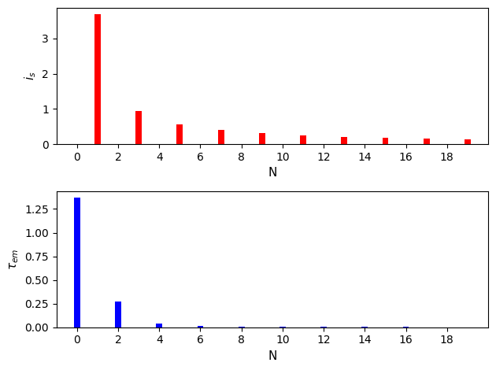

```python
import numpy as np
import matplotlib.pyplot as plt
import gseim_calc as calc
from setsize import set_size

f_hz = 50.0
T = 1.0/f_hz

slv = calc.slv("dcmc_1.in")

i_slv = 0
i_out = 0
filename = slv.l_filename_all[i_slv][i_out]
print('filename:', filename)
u = np.loadtxt(filename)
t = u[:, 0]

i_s = slv.get_array_double(i_slv,i_out,"i_s",u)
tem = slv.get_array_double(i_slv,i_out,"tem",u)

# compute Fourier coeffs:

t_start = 0.0
t_end = T

n_fourier = 20
coeff_i_s, thd_i_s = calc.fourier_coeff_1C(t, i_s,
    t_start, t_end, 1.0e-4*T, n_fourier)
print("THD (source current): ", "%5.2f"%(thd_i_s*100.0), "%")

coeff_tem, thd_tem = calc.fourier_coeff_1C(t, tem,
    t_start, t_end, 1.0e-4*T, n_fourier)

x = np.linspace(0, n_fourier, n_fourier+1)

y_i_s = np.array(coeff_i_s)
y_tem = np.array(coeff_tem)

fig, ax = plt.subplots(2, sharex=False)

bars1 = ax[0].bar(x, y_i_s, width=0.3, color='red' , label=r"$i_s$")
bars2 = ax[1].bar(x, y_tem, width=0.3, color='blue', label=r"$\tau_{em}}$")

for k in range(2):
    ax[k].set_xlabel('N', fontsize=11)
    ax[k].set_xlim(left=-1, right=n_fourier)
    ax[k].xaxis.set_ticks(np.arange(0, n_fourier, 2))


ax[0].set_ylabel(r'$i_s$'      , fontsize=11)
ax[1].set_ylabel(r'$\tau_{em}$', fontsize=11)

plt.tight_layout()
plt.show()
```

This notebook was contributed by **Prof. Nakul Narayanan K**, Govt. Engineering College, Thrissur. He may be contacted at nakul@gectcr.ac.in.